# Missing_value

Takahiro

2019/10/20

# Missing valuesがあるデータを扱います。

使用するデータセットはアメリカのGeneral Social Survey (GSS)のデータです。  
(dataはSourceDataに投入しました) 簡単に各項目の説明を書いておきます。

- **id:** respondant’s unique ID
- **health:** self-reported health level with 4 categories: poor, fair, good, excellent
- **partyid:** political party affiliation with categories dem, rep, or other
- **age:** age in years
- **sex:** male or female
- **sexornt:** sexual orientation with categories hetero, gay, or bisexual/other
- **educ:** number of years of formal education (capped at 20 years)
- **marital:** marital status with categories married, never married, and no longer married
- **race:** with categories black, white, and other
- **income:** in thousands of dollars

```r
library(tidyverse)
gsshealth <- read.csv("C:/Users/ogmcd/Dropbox/00_2019_Class/Fall/CS109A/Labnotes/data/gsshealth18.csv", header=TRUE)
str(gsshealth)
```

```
## 'data.frame':    1569 obs. of  10 variables:
##  $ id     : int  1 2 5 6 7 8 11 13 14 16 ...
##  $ health : Factor w/ 4 levels "excellent","fair",..: 3 1 1 3 3 1 1 4 1 3 ...
##  $ partyid: Factor w/ 3 levels "dem","other",..: 3 1 3 1 1 3 3 1 1 2 ...
##  $ age    : int  43 74 71 67 59 43 59 61 44 75 ...
##  $ sex    : Factor w/ 2 levels "female","male": 2 1 2 1 1 2 2 1 2 1 ...
##  $ sexornt: Factor w/ 3 levels "bisexual/other",..: 1 3 3 1 1 3 1 1 3 1 ...
##  $ educ   : int  14 10 18 16 13 12 19 13 16 12 ...
##  $ marital: Factor w/ 3 levels "married","never married",..: 2 3 3 3 3 2 3 3 1 3 ...
##  $ race   : Factor w/ 3 levels "black","other",..: 3 3 1 3 1 3 3 3 1 3 ...
##  $ income : num  NA NA NA NA 18.8 ...
```

```r
head(gsshealth)
```

```
##   id    health partyid age    sex        sexornt educ           marital
## 1  1      good     rep  43   male bisexual/other   14     never married
## 2  2 excellent     dem  74 female         hetero   10 no longer married
## 3  5 excellent     rep  71   male         hetero   18 no longer married
## 4  6      good     dem  67 female bisexual/other   16 no longer married
## 5  7      good     dem  59 female bisexual/other   13 no longer married
## 6  8 excellent     rep  43   male         hetero   12     never married
##    race income
## 1 white     NA
## 2 white     NA
## 3 black     NA
## 4 white     NA
## 5 black  18.75
## 6 white  37.50
```

health, partyid, sex, sexornt, marital, raceはfactorになっており扱いやすそうです。  
次はsummary commandでもう少し細かくデータの中身を調べます。

```r
gsshealth %>% summary
```

```
##        id             health     partyid         age            sex
##  Min.   :   1   excellent:359   dem  :708   Min.   :18.00   female:872
##  1st Qu.: 601   fair     :355   other:347   1st Qu.:33.00   male  :697
##  Median :1188   good     :771   rep  :514   Median :46.00
##  Mean   :1182   poor     : 84               Mean   :48.14
##  3rd Qu.:1769                               3rd Qu.:62.00
##  Max.   :2348                               Max.   :89.00
##                                             NA's   :2
##            sexornt         educ                    marital       race
##  bisexual/other:907   Min.   : 0.00   married          :655   black: 259
##  gay           : 22   1st Qu.:12.00   never married    :458   other: 173
##  hetero        :640   Median :14.00   no longer married:454   white:1137
##                       Mean   :13.79   NA's             :  2
##                       3rd Qu.:16.00
##                       Max.   :20.00
##                       NA's   :2
##      income
##  Min.   :  0.50
##  1st Qu.: 18.75
##  Median : 37.50
##  Mean   : 49.37
##  3rd Qu.: 67.50
##  Max.   :200.00
##  NA's   :661
```

idのMaxからわかる通り、連番になっていないことが少し気にかかりますが、まあ修正せずに行きましょう。 age, education, marital statusにそれぞれ2名ずつ、incomeには661名のNAがあることがわかります。  
incomeは一旦置いておいて、他の3つの変数で、missing valuesがどこにあるかどうかを調べます。

```r
which (is.na(gsshealth$age))
```

```
## [1]  959 1316
```

```r
which (is.na(gsshealth$educ))
```

```
## [1]  530 1547
```

```r
which (is.na(gsshealth$marital))
```

```
## [1]   26 1479
```

### なお、skimrというパッケージが欠損データの確認に便利です。

```r
library('skimr')
gsshealth %>% skimr::skim()
```

```
## Skim summary statistics
##  n obs: 1569
##  n variables: 10
##
## -- Variable type:factor -----------------------------------------------------------------------------
##  variable missing complete    n n_unique
##    health       0     1569 1569        4
##   marital       2     1567 1569        3
##   partyid       0     1569 1569        3
##      race       0     1569 1569        3
##       sex       0     1569 1569        2
##   sexornt       0     1569 1569        3
##                             top_counts ordered
##  goo: 771, exc: 359, fai: 355, poo: 84   FALSE
##    mar: 655, nev: 458, no : 454, NA: 2   FALSE
##    dem: 708, rep: 514, oth: 347, NA: 0   FALSE
##   whi: 1137, bla: 259, oth: 173, NA: 0   FALSE
##              fem: 872, mal: 697, NA: 0   FALSE
##     bis: 907, het: 640, gay: 22, NA: 0   FALSE
##
## -- Variable type:integer ----------------------------------------------------------------------------
##  variable missing complete    n    mean     sd p0 p25  p50  p75 p100
##       age       2     1567 1569   48.14  18.23 18  33   46   62   89
##      educ       2     1567 1569   13.79   2.93  0  12   14   16   20
##        id       0     1569 1569 1182.41 675.57  1 601 1188 1769 2348
##      hist
##  ▆▇▇▆▆▆▃▂
##  ▁▁▁▂▇▇▆▂
##  ▇▇▇▇▇▇▇▇
##
## -- Variable type:numeric ----------------------------------------------------------------------------
##  variable missing complete    n  mean    sd  p0   p25  p50  p75 p100
##    income     661      908 1569 49.37 45.13 0.5 18.75 37.5 67.5  200
##      hist
##  ▇▇▃▂▁▁▁▁
```

binary outcomeとして、healthをpoorとそれ以外に分類します。

```r
gsshealth <-
  mutate(gsshealth, poorhealth = if_else(health=='poor', true = 1, false = 0))
```

Original datasetをいじると後から大変なので、一旦copyしておきます。

```r
gsscopy <- data.frame(gsshealth)
```

maritalとeducが欠損している人の年齢を見てみます。

```r
print(gsscopy$age[is.na(gsscopy$marital)])
```

```
## [1] 50 65
```

```r
print(gsscopy$age[is.na(gsscopy$educ)])
```

```
## [1] 24 75
```

まずmaritalについては、結婚していておかしくない年齢なので、marriedを入れましょう。  
educについても、学生ではないことが確認できたので、13年を代入しておきます。  
educの13年はアメリカで言うところの高卒です。  
ageには中央値を入れることに決めました。  
全て恣意的な作業なので、もちろん正当性が担保されているわけではありません。

```r
gsscopy$marital[is.na(gsscopy$marital)] <- 'married'
gsscopy$educ[is.na(gsscopy$educ)] <- 13
gsscopy$educ <- as.integer(gsscopy$educ)
gsscopy$age[is.na(gsscopy$age)] <- median(gsscopy$age, na.rm = TRUE)
str(gsscopy)
```

```
## 'data.frame':    1569 obs. of  11 variables:
##  $ id        : int  1 2 5 6 7 8 11 13 14 16 ...
##  $ health    : Factor w/ 4 levels "excellent","fair",..: 3 1 1 3 3 1 1 4 1 3 ...
##  $ partyid   : Factor w/ 3 levels "dem","other",..: 3 1 3 1 1 3 3 1 1 2 ...
##  $ age       : int  43 74 71 67 59 43 59 61 44 75 ...
##  $ sex       : Factor w/ 2 levels "female","male": 2 1 2 1 1 2 2 1 2 1 ...
##  $ sexornt   : Factor w/ 3 levels "bisexual/other",..: 1 3 3 1 1 3 1 1 3 1 ...
##  $ educ      : int  14 10 18 16 13 12 19 13 16 12 ...
##  $ marital   : Factor w/ 3 levels "married","never married",..: 2 3 3 3 3 2 3 3 1 3 ...
##  $ race      : Factor w/ 3 levels "black","other",..: 3 3 1 3 1 3 3 3 1 3 ...
##  $ income    : num  NA NA NA NA 18.8 ...
##  $ poorhealth: num  0 0 0 0 0 0 0 1 0 0 ...
```

```r
gsscopy %>% summary
```

```
##        id             health     partyid         age            sex
##  Min.   :   1   excellent:359   dem  :708   Min.   :18.00   female:872
##  1st Qu.: 601   fair     :355   other:347   1st Qu.:33.00   male  :697
##  Median :1188   good     :771   rep  :514   Median :46.00
##  Mean   :1182   poor     : 84               Mean   :48.13
##  3rd Qu.:1769                               3rd Qu.:62.00
##  Max.   :2348                               Max.   :89.00
##
##            sexornt         educ                    marital       race
##  bisexual/other:907   Min.   : 0.00   married          :657   black: 259
##  gay           : 22   1st Qu.:12.00   never married    :458   other: 173
##  hetero        :640   Median :14.00   no longer married:454   white:1137
##                       Mean   :13.78
##                       3rd Qu.:16.00
##                       Max.   :20.00
##
##      income         poorhealth
##  Min.   :  0.50   Min.   :0.00000
##  1st Qu.: 18.75   1st Qu.:0.00000
##  Median : 37.50   Median :0.00000
##  Mean   : 49.37   Mean   :0.05354
##  3rd Qu.: 67.50   3rd Qu.:0.00000
##  Max.   :200.00   Max.   :1.00000
##  NA's   :661
```

問題のincomeですが、試しにmedianを入れてみます。

```r
gsscopy <-
  mutate(gsscopy, income_median = if_else(is.na(gsscopy$income), true = median(gsscopy$income, na.rm = TRUE), false = gsscopy$income))
gsscopy %>% summary
```

```
##        id             health     partyid         age            sex
##  Min.   :   1   excellent:359   dem  :708   Min.   :18.00   female:872
##  1st Qu.: 601   fair     :355   other:347   1st Qu.:33.00   male  :697
##  Median :1188   good     :771   rep  :514   Median :46.00
##  Mean   :1182   poor     : 84               Mean   :48.13
##  3rd Qu.:1769                               3rd Qu.:62.00
##  Max.   :2348                               Max.   :89.00
##
##            sexornt         educ                    marital       race
##  bisexual/other:907   Min.   : 0.00   married          :657   black: 259
##  gay           : 22   1st Qu.:12.00   never married    :458   other: 173
##  hetero        :640   Median :14.00   no longer married:454   white:1137
##                       Mean   :13.78
##                       3rd Qu.:16.00
##                       Max.   :20.00
##
##      income         poorhealth      income_median
##  Min.   :  0.50   Min.   :0.00000   Min.   :  0.50
##  1st Qu.: 18.75   1st Qu.:0.00000   1st Qu.: 32.50
##  Median : 37.50   Median :0.00000   Median : 37.50
##  Mean   : 49.37   Mean   :0.05354   Mean   : 44.37
##  3rd Qu.: 67.50   3rd Qu.:0.00000   3rd Qu.: 45.00
##  Max.   :200.00   Max.   :1.00000   Max.   :200.00
##  NA's   :661
```

さて、ここでincomeのヒストグラムを見てみましょう。  
medianで補完したものと補完していないものを比べてみます。

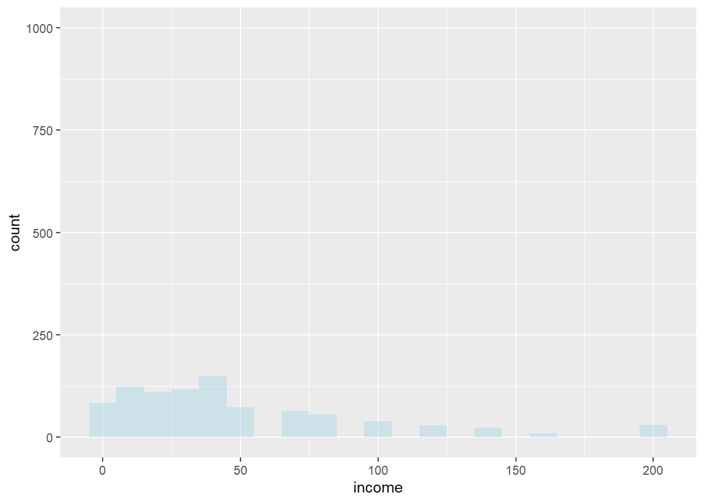

```r
hist_inc <- ggplot(data = gsscopy,
                   mapping = aes(x = income))
hist_inc + geom_histogram(binwidth = 10, alpha = 0.5, fill = 'lightblue') + ylim(0, 1000)
```

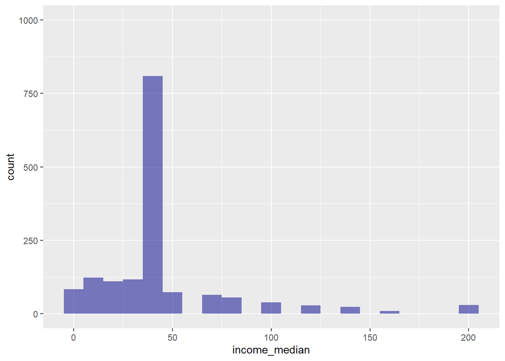

```r
hist_inc_median <- ggplot(data = gsscopy,
                   mapping = aes(x = income_median))
hist_inc_median + geom_histogram(binwidth = 10, alpha = 0.5, fill = 'darkblue') + ylim(0,1000)
```

極めて当たり前のことですが、medianの部分にすごく高いspikeができてしまい、かなり不自然な分布です。  
もう少しいい補完方法を考えたいところです。  
そこで、gsscopyのincomeのmissing valuesをその他の変数から予測することにしましょう。  
まず、一旦missingを除外して、目的変数をincome, 説明変数をその他の変数としたLinear Regressionを作ります。  
その次に、missingのみのdatasetにLinear Regressionをあてはめ、missingの値を予測します。

```r
gsscopy2 <-
  na.omit(gsscopy)
gsscopy2 %>% head
```

```
##    id    health partyid age    sex        sexornt educ           marital
## 5   7      good     dem  59 female bisexual/other   13 no longer married
## 6   8 excellent     rep  43   male         hetero   12     never married
## 7  11 excellent     rep  59   male bisexual/other   19 no longer married
## 9  14 excellent     dem  44   male         hetero   16           married
## 10 16      good   other  75 female bisexual/other   12 no longer married
## 12 19 excellent     dem  40 female         hetero   20 no longer married
##     race income poorhealth income_median
## 5  black  18.75          0         18.75
## 6  white  37.50          0         37.50
## 7  white 120.00          0        120.00
## 9  black 100.00          0        100.00
## 10 white  11.25          0         11.25
## 12 white  67.50          0         67.50
```

ちなみに、Rは回帰分析の際に自動でmissing valueをomitするので、↑の工程はあってもなくても変わりません。  
さて、回帰分析でmissingを予測します。 なお、“add_predictions”というfunctionを使うために、modelrというlibraryが必要です。

```r
library(modelr)
model_income <- lm(income ~ health + partyid + age + sex + sexornt + educ + marital + race, data = gsscopy2)
gsscopy_imputed <-
  gsscopy %>%
    add_predictions(model = model_income, var = "income_pred") %>%
    mutate(income_imputed=if_else(condition = is.na(income),
                                  true = income_pred,
                                  false = income %>% as.double())) %>%
  select(-income_pred)
gsscopy$income %>% summary
```

```
##    Min. 1st Qu.  Median    Mean 3rd Qu.    Max.    NA's
##    0.50   18.75   37.50   49.37   67.50  200.00     661
```

```r
gsscopy_imputed$income_imputed %>% summary
```

```
##    Min. 1st Qu.  Median    Mean 3rd Qu.    Max.
##  -18.66   21.25   41.95   47.69   65.26  200.00
```

```r
library(jtools)
Log_model_single_imp <- glm(poorhealth ~ partyid + age + sex + sexornt + educ + marital + race + income, family = binomial(link = 'logit'), data = gsscopy_imputed)
summ(Log_model_single_imp, exp = TRUE, confint = TRUE, digits = 3)
```

| Observations | 908 (661 missing obs. deleted) |
| --- | --- |
| Dependent variable | poorhealth |
| Type | Generalized linear model |
| Family | binomial |
| Link | logit |

| χ²(12) | 18.472 |
| --- | --- |
| Pseudo-R² (Cragg-Uhler) | 0.096 |
| Pseudo-R² (McFadden) | 0.086 |
| AIC | 222.025 |
| BIC | 284.571 |

|  | exp(Est.) | 2.5% | 97.5% | z val. | p |
| --- | --- | --- | --- | --- | --- |
| (Intercept) | 0.033 | 0.002 | 0.591 | -2.317 | 0.020 |
| partyidother | 1.138 | 0.405 | 3.194 | 0.245 | 0.806 |
| partyidrep | 0.868 | 0.294 | 2.561 | -0.256 | 0.798 |
| age | 1.020 | 0.987 | 1.055 | 1.180 | 0.238 |
| sexmale | 0.944 | 0.385 | 2.314 | -0.127 | 0.899 |
| sexorntgay | 0.000 | 0.000 | Inf | -0.012 | 0.991 |
| sexornthetero | 0.543 | 0.207 | 1.424 | -1.241 | 0.215 |
| educ | 0.925 | 0.802 | 1.067 | -1.071 | 0.284 |
| maritalnever married | 2.212 | 0.701 | 6.980 | 1.354 | 0.176 |
| maritalno longer married | 1.157 | 0.368 | 3.637 | 0.250 | 0.802 |
| raceother | 2.377 | 0.499 | 11.330 | 1.087 | 0.277 |
| racewhite | 1.710 | 0.450 | 6.504 | 0.787 | 0.431 |
| income | 0.981 | 0.963 | 1.000 | -1.949 | 0.051 |

Standard errors: MLE

また、このモデルではuncertaintyを考慮していないので不自然なdatasetになります。 uncertaintyとは、
$$Y = \beta_0 + \beta_1X_1 + \cdots + \beta_nX_n + \epsilon$$
における
$$\epsilon$$
のことです。
ここを改善し何回も代入して多数のdatasetを作り、それぞれで解析して結果を統合するのがmultiple imputationです。
では実際にやってみます。
使用するのは、miceというlibraryになります。

```r
gss_mi <- data.frame(gsshealth)
library(mice)
imp <- mice(gss_mi,
            m = 10,
            maxit = 50,
            method = "pmm",
            printFlag = FALSE)
summary(imp)
```

```
## Class: mids
## Number of multiple imputations:  10
## Imputation methods:
##         id     health    partyid        age        sex    sexornt
##         ""         ""         ""      "pmm"         ""         ""
##       educ    marital       race     income poorhealth
##      "pmm"      "pmm"         ""      "pmm"         ""
## PredictorMatrix:
##         id health partyid age sex sexornt educ marital race income
## id       0      1       1   1   1       1    1       1    1      1
## health   1      0       1   1   1       1    1       1    1      1
## partyid  1      1       0   1   1       1    1       1    1      1
## age      1      1       1   0   1       1    1       1    1      1
## sex      1      1       1   1   0       1    1       1    1      1
## sexornt  1      1       1   1   1       0    1       1    1      1
##         poorhealth
## id               1
## health           1
## partyid          1
## age              1
## sex              1
## sexornt          1
## Number of logged events:  2000
##   it im     dep meth        out
## 1  1  1     age  pmm poorhealth
## 2  1  1    educ  pmm healthpoor
## 3  1  1 marital  pmm poorhealth
## 4  1  1  income  pmm healthpoor
## 5  1  2     age  pmm healthpoor
## 6  1  2    educ  pmm poorhealth
```

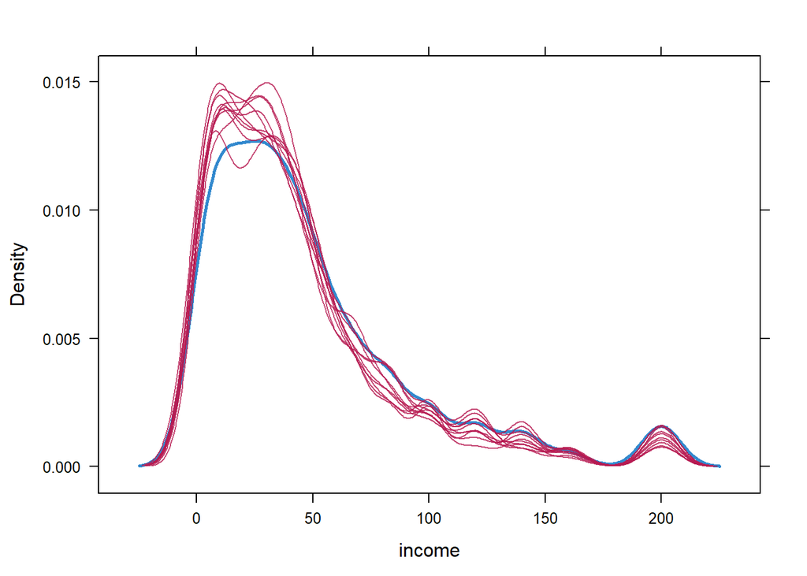

```r
densityplot(imp)
```

magrittrというlibraryを用いて、imputation dataでのlogistic regressionの結果を統合します。

```r
library(magrittr)
combine <- imp %>%
  with(glm(poorhealth ~ partyid + age + sex + sexornt + educ + marital + race + income, family = binomial(link = 'logit')))
#round(summary(pool(combine)), 3)
round(summary(pool(combine), conf.int = TRUE, exponentiate = TRUE), 3)
```

```
##                          estimate std.error statistic       df p.value
## (Intercept)                 0.037     0.782    -4.222 1434.600   0.000
## partyidother                1.077     0.297     0.250 1229.874   0.802
## partyidrep                  0.868     0.292    -0.485 1447.141   0.628
## age                         1.027     0.008     3.580 1456.946   0.000
## sexmale                     1.413     0.260     1.332  345.168   0.184
## sexorntgay                  0.907     1.071    -0.091 1461.505   0.927
## sexornthetero               0.624     0.259    -1.824 1461.230   0.068
## educ                        0.913     0.046    -1.960  151.302   0.052
## maritalnever married        1.959     0.347     1.941  799.683   0.053
## maritalno longer married    1.460     0.295     1.283 1499.042   0.200
## raceother                   1.828     0.477     1.264 1525.076   0.206
## racewhite                   2.033     0.375     1.893 1530.849   0.059
## income                      0.981     0.011    -1.727   13.763   0.107
##                          2.5 % 97.5 %
## (Intercept)              0.008  0.171
## partyidother             0.601  1.930
## partyidrep               0.489  1.540
## age                      1.012  1.042
## sexmale                  0.848  2.355
## sexorntgay               0.111  7.417
## sexornthetero            0.375  1.036
## educ                     0.834  1.001
## maritalnever married     0.992  3.869
## maritalno longer married 0.819  2.602
## raceother                0.717  4.665
## racewhite                0.975  4.239
## income                   0.958  1.005
```

最後に統合したAUROCを求めようとしましたが、上手く行きませんでした。  
誰か助けていただけると。